# ACDI/VOCA R Policy

2020-03-13 17:20:34

2019-04-11 10:43:35

[figure not shown]

## RStudio

RStudio is an IDE for the R programming language and is the IDE of choice for ACDI/VOCA for using R. Split into two editions, RStudio for Desktop and RStudio Server, it is an incredibly empowering tool that allows one to use R to its full potential. The different panels in RStudio such as “Environment”, “Files”, “Help”, “History” allows for easy organization and interacting with all the files and objects in your analysis.

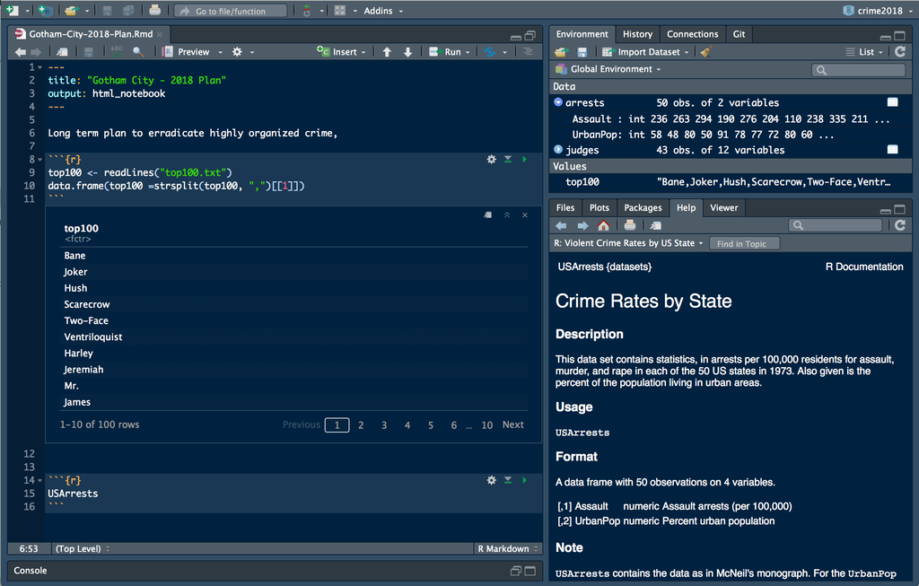

[figure not shown]

[figure not shown]

Above is what a RStudio set up might look like. You can spend time to position and size each of the panels however you want along with a great many other aesthetical aspects like the code font and color.

## R Projects

Using R Projects is a vital part of keeping your work separately contained with its own working directory, workspace, history, and source documents. Instead of cluttering up your environment with multiple objects from multiple projects you can have a number of different projects opened in its own window so things from one project won’t interfere with another.

A great resource to get started with R Projects is [here](https://support.rstudio.com/hc/en-us/articles/200526207-Using-Projects).

For a general overview of a project-oriented workflow in R, consult this website (still work-in-progress) [here](https://whattheyforgot.org/project-oriented-workflow.html) written by Jenny Bryan and Jim Hester from R Studio. For a shorter blogpost version of the above see [here](https://www.tidyverse.org/articles/2017/12/workflow-vs-script/).

## GitHub

Now that you have everything organized by using Projects you might want to backup and version control your code and analyses using GitHub. Using GitHub will also allow you to coordinate and collaborate with other analysts on the same project, you will never again have to search your email for “datafile_revised.data” or “final_final_final_draft3.doc”!

A great introduction to switching over to a version control system for your projects can be read [here](https://peerj.com/preprints/3159/).

For connecting your RStudio Project to Git and GitHub check out this [chapter](https://happygitwithr.com/rstudio-git-github.html) of the book, “Happy Git with R” by Jenny Bryan.

## The Tidyverse and Coding Style

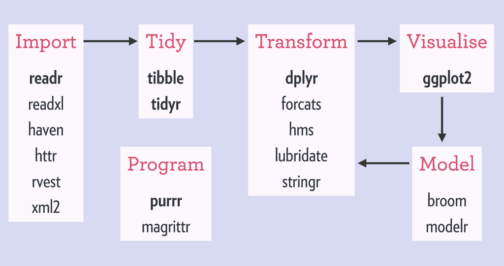

[figure not shown]

The Tidyverse is a set of R packages specifically designed for doing data science. The packages are consistent in their underlying design and structure which makes it very easy to learn. In regards to syntax and coding style, ACDI VOCA follows the [tidyverse style guide](https://style.tidyverse.org/) for consistent development of our code and tools. One of the main strengths of the tidyverse is that the code is very easily readable by a human compared to base R code. Some great examples of this can be seen [here](https://tavareshugo.github.io/data_carpentry_extras/base-r_tidyverse_equivalents/base-r_tidyverse_equivalents.html) in a great webpage that shows how to do something in both base R and the tidyverse!

The best way to get oriented with the tidyverse packages is to go through Hadley Wickham’s [R for Data Science](https://r4ds.had.co.nz/) book which is provided online and for free! You can also go visit the Slack group for R4DS [here](https://rfordatascience.slack.com/) to get online help.

Some particular notes on how we write R code:

- For commenting lines out we use ONE `#` whereas if we want to make a comment in the code we use TWO `##`.

```r
data %>%
  select(this, that, everything()) %>%
  ## Calculate values here:
  mutate(nutrition10 = nutrition * 10,
         ham_production = ham + production - costs) %>%
  ## We need to filter by values over 5000:
  filter(nutrition10 > 5000) %>%
  ## No need to arrange by DESC order anymore:
  #arrange(desc(nutrition10))
```

- Avoid using `for` loops or the `apply()` family of functions (`sapply`, `lapply`, `vapply`, etc.) and use the `map()` functions from the `purrr` package instead. Note that there is nothing wrong with using `for` loops in R necessarily but we want to keep everything consistent across the codebase.

```r
library(tidyverse)
```

[output not shown]